# Type D Data Wrangle

Water Department - County of Inyo

30 November, 2020

[Github Repo](https://github.com/zach-nelson/riparian)

```r
library(knitr) #how R code and text turn into interactive word, pdf, or html-based documents
library(googlesheets4) #
library(googledrive)
library(tidyverse) #dplyr, tidyr etc
# library(DT)#html widget for data tables [searchable, sortable, with pagitation and set record number per page and filter by categories]

# library(knitr) #how R code and text turn into interactive word, pdf, or html-based documents
# library(googledrive)
library(gargle)
library(janitor)
library(stringr)#dplyr, tidyr etc

library(rmarkdown)

# spatial
library(sp)
library(rgdal)
library(sf)
library(tmaptools)
library(tmap)
library("RColorBrewer")

gs4_deauth()
knitr::opts_chunk$set(echo = TRUE, message=FALSE, warning=FALSE, cache=TRUE)
```

# Read Data

Google sheets API is used to pull the most recent data

```r
# set to deauthorize for now. meaning the data set is temporarily set to public view with link. This way we don't have to worry about authenticating google account.

gs4_deauth()

# this is the url of the sheet copied from browser
gsheet.url <- "https://docs.google.com/spreadsheets/d/1hytlt3tk_mq-nEeVIHuYIC16CVfONP-x0XYLJRMI5jg/edit?usp=sharing"

# get metadata from sheet
gs4_get(gsheet.url)
```

```
##   Spreadsheet name: MJ Type D Data 2020
##                 ID: 1hytlt3tk_mq-nEeVIHuYIC16CVfONP-x0XYLJRMI5jg
##             Locale: en_US
##          Time zone: America/Los_Angeles
##        # of sheets: 11
##
##           (Sheet name): (Nominal extent in rows x columns)
##             lpi-3 tier: 2095 x 25
##        belt-tree-count: 1018 x 40
##                Revisit: 1000 x 40
## Spherical Densiometer : 1133 x 29
##        fluvial surface: 1015 x 28
##                   soil: 1022 x 29
##          TreeCoreTally: 1017 x 27
##                    SWE: 981 x 95
##    completed transects: 1015 x 36
##         dropdown lists: 1004 x 26
##          Pivot Table 1: 1000 x 219
##
## (Named range): (A1 range)
##   NamedRange1: 'belt-tree-count'!E:E
```

```r
# store the sheet id for future reference. May be more stable than the url and is nicer to look at.
ssid <- "1hytlt3tk_mq-nEeVIHuYIC16CVfONP-x0XYLJRMI5jg"
```

sheet properties

```r
# this function declares the string to be a Sheet ID in case we mix the workflow with googledrive library of functions which assume character sting is a file name or path.

ssid <- as_sheets_id("1hytlt3tk_mq-nEeVIHuYIC16CVfONP-x0XYLJRMI5jg")
sheet_properties(ssid)
```

| name | index | id | type | visible | grid_rows | grid_columns | data |
| --- | --- | --- | --- | --- | --- | --- | --- |
| lpi-3 tier | 0 | 1559210775 | GRID | TRUE | 2095 | 25 |  |
| belt-tree-count | 1 | 829775726 | GRID | TRUE | 1018 | 40 |  |
| Revisit | 2 | 1722100722 | GRID | TRUE | 1000 | 40 |  |
| Spherical Densiometer | 3 | 162490489 | GRID | TRUE | 1133 | 29 |  |
| fluvial surface | 4 | 1319211795 | GRID | TRUE | 1015 | 28 |  |
| soil | 5 | 1137699681 | GRID | TRUE | 1022 | 29 |  |
| TreeCoreTally | 6 | 874712968 | GRID | TRUE | 1017 | 27 |  |
| SWE | 7 | 1368192475 | GRID | TRUE | 981 | 95 |  |
| completed transects | 8 | 704833717 | GRID | TRUE | 1015 | 36 |  |
| dropdown lists | 9 | 1706428147 | GRID | TRUE | 1004 | 26 |  |

[output cut: 1 more lines]

worksheet names

```r
sheet_names(ssid)
```

```
##  [1] "lpi-3 tier"             "belt-tree-count"        "Revisit"
##  [4] "Spherical Densiometer " "fluvial surface"        "soil"
##  [7] "TreeCoreTally"          "SWE"                    "completed transects"
## [10] "dropdown lists"         "Pivot Table 1"
```

## Line Point Data

count data - species recorded in each of 3-tiers every meter. Transect length variable

```r
lpi <- read_sheet(ssid) %>% clean_names()
paged_table(lpi)
```

| filter_id | date | obs | position | x1_5_m_code | x1_5_5_m_code | x5_m_code | bare_soil | verified | species | common_name | order | family | genus | lifecycle | lifeform | veg_type | source | source_abr | phreatophyte | notes |
| --- | --- | --- | --- | --- | --- | --- | --- | --- | --- | --- | --- | --- | --- | --- | --- | --- | --- | --- | --- | --- |
| 76_LORP Reach 3on | 2020-07-09 | MJ | 1.0 | Code | TYPHA | SAGO | NA | FALSE | Artemisia tridentata | sagebrush, Big | Asterales | Asteraceae | Artemisia | Perennial | Shrub | shrub | Joint Monitoring 2015-current year | jm | 0 | example |
| 76_LORP Reach 3on | 2020-07-09 | MJ | 2.0 | GLLE3 | SAGO | SAGO | NA | FALSE | NA | NA | NA | NA | NA | NA | NA | NA | NA | NA | NA | Last reading hard to take with middle canopy in the way... telescoping rod? |
| 76_LORP Reach 3on | 2020-07-09 | MJ | 3.0 | SAGO | SAGO | NA | NA | FALSE | NA | NA | NA | NA | NA | NA | NA | NA | NA | NA | NA | NA |
| 76_LORP Reach 3on | 2020-07-09 | MJ | 4.0 | NA | SAGO | NA | NA | FALSE | NA | NA | NA | NA | NA | NA | NA | NA | NA | NA | NA | NA |
| 76_LORP Reach 3on | 2020-07-09 | MJ | 5.0 | ERNA10 | NA | NA | NA | FALSE | NA | NA | NA | NA | NA | NA | NA | NA | NA | NA | NA | NA |
| 76_LORP Reach 3on | 2020-07-09 | MJ | 6.0 | NA | NA | NA | NA | FALSE | NA | NA | NA | NA | NA | NA | NA | NA | NA | NA | NA | NA |
| 76_LORP Reach 3on | 2020-07-09 | MJ | 7.0 | STEPH | NA | NA | NA | FALSE | NA | NA | NA | NA | NA | NA | NA | NA | NA | NA | NA | NA |
| 76_LORP Reach 3on | 2020-07-09 | MJ | 8.0 | Code | NA | NA | NA | FALSE | NA | NA | NA | NA | NA | NA | NA | NA | NA | NA | NA | End of transect. No plants. |
| 462_MORP Reach 5on | 2020-07-13 | JZ | 1.0 | EUOC4 | NA | NA | NA | FALSE | NA | NA | NA | NA | NA | NA | NA | NA | NA | NA | NA | NA |
| 462_MORP Reach 5on | 2020-07-13 | JZ | 2.0 | SAEX | TARA | NA | NA | FALSE | NA | NA | NA | NA | NA | NA | NA | NA | NA | NA | NA | NA |

[output cut: 2084 more lines]

## Belt Transect Individual Tree Data

Includes individual tree rows with dbh, height etc

```r
# Clean up the names automatically
belt.count <- read_sheet(ssid, sheet = "belt-tree-count")%>% clean_names()
paged_table(belt.count)
```

| filter_id | date | obs | location_on_tape_centerline_m | r_or_l_of_centerline_facing_transect_end_points | distance_from_centerline_m | circumference | dbh_cm | ht_dbh_m_basal_0 | potential_canopy_cover_percent | tree_height_m | species | trunk_angle_degree | size_class_main_trunk_see_table | size_class_resprout | cored_y_n | if_cored_gps_point_number | clone_vegetative_reprod | type_sprout_branch_or_stump | number_resprout_estimate | notes | x22 | x23 | hydro_notes_w_keith |
| --- | --- | --- | --- | --- | --- | --- | --- | --- | --- | --- | --- | --- | --- | --- | --- | --- | --- | --- | --- | --- | --- | --- | --- |
| 76_LORP Reach 3on | 2020-07-09 | MJ | 0.00 | R | 0.00 | 84.00 | 26.751592 | 7.60 | 55 | 7.00 | SAGO | NA | O | NA | yes | 76_LORP_R3_on_t1_SALA3 | NA | NA | NA | Height, potential canopy, core sample taken on 9/30/2020. Only 1 core taken because pith capured (we think) | NA | NA | NA |
| 76_LORP Reach 3on | 2020-07-09 | MJ | 2.00 | R | 0.50 | 120.00 | 38.216561 | 6.40 | 75 | 6.10 | SAGO | NA | O | NA | NA | NA | NA | NA | NA | Main trunk severely damaged & many small living limbs have kept tree alive. Height potential canopy taken on 9/30/2020 | NA | NA | NA |
| 76_LORP Reach 3on | 2020-07-09 | MJ | 1.00 | R | 2.50 | 143.00 | 45.541401 | 5.00 | 25 | 5.60 | SAGO | NA | O | NA | NA | NA | NA | NA | NA | Main trunk severely damaged, a few large stump-sprouts alive. Height potential canopy taken on 9/30/2020 | NA | NA | NA |
| 462_MORP Reach 5on | 2020-07-13 | MJ | 2.00 | R | 3.00 | 36.00 | 11.464968 | 0.50 | 95 | 5.50 | TARA | NA | P | NA | NA | NA | NA | NA | NA | Has multiple stems. DBH taken at 0.5 m | NA | NA | NA |
| 462_MORP Reach 5on | 2020-07-13 | MJ | 5.00 | R | 5.00 | 65.00 | 20.700637 | 0.50 | 75 | 4.50 | TARA | NA | O | NA | NA | NA | NA | NA | NA | Has multiple stems. DBH taken at 0.5 m | NA | NA | NA |
| 462_MORP Reach 5on | 2020-07-13 | MJ | 14.00 | R | 0.75 | 135.00 | 42.993631 | 0.50 | 10 | 7.80 | SALA3 | 45 | O | NA | NA | NA | NA | NA | NA | DBH taken at 0.5 m. Main trunk broken at 3-4m. Beaver activity present on smaller resprouted limbs | NA | NA | NA |
| 462_MORP Reach 5on | 2020-07-13 | MJ | 14.70 | R | 0.75 | 150.00 | 47.770701 | NA | 30 | 7.30 | SALA3 | 35 | O | NA | NA | NA | NA | NA | NA | Main trunk severely damaged at 4m | NA | NA | NA |
| 462_MORP Reach 5on | 2020-07-13 | MJ | 14.70 | L | 0.00 | 150.00 | 47.770701 | NA | 75 | 7.60 | SALA3 | 10 | O | NA | NA | NA | NA | NA | NA | NA | NA | NA | NA |
| 462_MORP Reach 5on | 2020-07-13 | MJ | 14.90 | R | 2.00 | 167.00 | 53.184713 | NA | 50 | 6.90 | SALA3 | 40 | L | NA | Y | 462_MORP_R5_on_t1_SALA3 | NA | NA | NA | Core was rotten in middle | NA | NA | NA |
| 462_MORP Reach 5on | 2020-07-13 | MJ | 16.00 | R | 0.50 | 115.00 | 36.624204 | NA | 5 | 2.10 | SALA3 | NA | O | NA | NA | NA | NA | NA | NA | main trunk severed at 0.5m resprout | NA | NA | NA |

[output cut: 765 more lines]

## Spherical Densiometer - Overhead Canopy Cover

Canopy cover from spherical densiometer, 4 directions every 10 m

```r
# gs4_deauth()
s.dens <- read_sheet(ssid, sheet = "Spherical Densiometer ") %>% clean_names()
paged_table(s.dens)
```

| filter_id | location_m_on_transect_example | sd_green_reading_out_of_96 | direction | x0 | fluvial_surface | notes | densiometer_at_start_point_or_at_regular_intervals_given_here |
| --- | --- | --- | --- | --- | --- | --- | --- |
| 76_LORP Reach 3on | 0 | 57 | Facing channel | NA | channel | On edge of channel/bank | NA |
| 76_LORP Reach 3on | 0 | 31 | Upstream | NA | channel | NA | NA |
| 76_LORP Reach 3on | 0 | 23 | Downstream | NA | channel | NA | NA |
| 76_LORP Reach 3on | 0 | 53 | Facing bank | NA | channel | NA | NA |
| 462_MORP Reach 5on | 0 | 3 | facing channel | NA | NA | NA | NA |
| 462_MORP Reach 5on | 0 | 10 | Upstream | NA | NA | NA | NA |
| 462_MORP Reach 5on | 0 | 13 | Facing bank | NA | NA | NA | NA |
| 462_MORP Reach 5on | 0 | 1 | Downstream | NA | NA | NA | NA |
| 462_MORP Reach 5on | 10 | 5 | Facing channel | NA | NA | NA | NA |
| 462_MORP Reach 5on | 10 | 0 | Upstream | NA | NA | NA | NA |

[output cut: 726 more lines]

## Fluvial Surface

```r
#  "lpi-3 tier"             "belt-tree-count"        "Spherical Densiometer "
#  [4] "fluvial surface"        "soil"                   "TreeCoreTally"
#  [7] "SWE"                    "completed transects"    "dropdown lists"
# [10] "Pivot Table 1"
fluv.surf <- read_sheet(ssid, sheet = "fluvial surface")%>% clean_names()
paged_table(fluv.surf)
```

| filter_id | date | obs | location_m_on_transect | fluvial_surface | notes | bank_angle | bank_height_depth_m |
| --- | --- | --- | --- | --- | --- | --- | --- |
| 76_LORP Reach 3on | 2020-07-09 | MJ | 0.0 | channel | On edge of channel/bank | NA | 0-5 |
| 76_LORP Reach 3on | 2020-09-30 | MJ | 0.8 | bank | NA | NA | NA |
| 76_LORP Reach 3on | 2020-09-30 | MJ | 1.0 | floodplain | Steep floodplain angle | Steep >45 deg | NA |
| 76_LORP Reach 3on | 2020-07-09 | MJ | 4.0 | terrace | NA | NA | NA |
| 462_MORP Reach 5on | 2020-07-13 | MJ | 0.0 | bank | NA | NA | NA |
| 462_MORP Reach 5on | 2020-07-13 | MJ | 1.0 | floodplain | NA | NA | NA |
| 462_MORP Reach 5on | 2020-07-13 | MJ | 24.0 | terrace | NA | NA | NA |
| 479_MORP Reach 5on | 2020-07-13 | MJ | 0.0 | bank | NA | NA | NA |
| 479_MORP Reach 5on | 2020-07-13 | MJ | 1.0 | floodplain | NA | NA | NA |
| 479_MORP Reach 5on | 2020-07-13 | MJ | 25.0 | terrace | * double-check this reading! (since it was early-on and transect is longer than 25m, just want to make sure | NA | NA |

[output cut: 122 more lines]

notes data types imported fine. I haven’t done anything with this yet (11/9/20 zn)

## Soil

```r
#  "lpi-3 tier"             "belt-tree-count"        "Spherical Densiometer "
#  [4] "fluvial surface"        "soil"                   "TreeCoreTally"
#  [7] "SWE"                    "completed transects"    "dropdown lists"
# [10] "Pivot Table 1"
soil <- read_sheet(ssid, sheet = "soil")%>% clean_names()
paged_table(soil)
```

| filter_id | date | obs | location_m_on_transect_example | sample_id | litter_depth_cm | crust_present_y_n | surface_1_2_in_collected_separately_y_n | notes |
| --- | --- | --- | --- | --- | --- | --- | --- | --- |
| 565_MORP Reach 6onfire | 2020-07-20 | DG | 4.0 | 565_MORP_R6_onfire_s1 |  | N | NA | NA |
| 565_MORP Reach 6onfire | 2020-07-20 | DG | 7.0 | 565_MORP_R6_onfire_s2 |  | N | NA | NA |
| 565_MORP Reach 6onfire | 2020-07-20 | DG | 15.0 | 565_MORP_R6_onfire_s2 |  | N | NA | NA |
| 565_MORP Reach 6onfire | 2020-07-20 | DG | 24.0 | 565_MORP_R6_onfire_s2 |  | NA | NA | NA |
| 565_MORP Reach 6onfire | 2020-07-20 | DG | 33.0 | 565_MORP_R6_onfire_s3 |  | NA | NA | NA |
| 565_MORP Reach 6onfire | 2020-07-20 | DG | NA | 565_MORP_R6_onfire_s3 |  | NA | NA | NA |
| 565_MORP Reach 6onfire | 2020-07-20 | DG | 86.0 | 565_MORP_R6_onfire_s3 |  | NA | NA | NA |
| 565_MORP Reach 6onfire | 2020-07-20 | DG | 100.0 | 565_MORP_R6_onfire_s4 |  | NA | NA | NA |
| 547_MORP Reach 6onfire | 2020-07-23 | MJ | 0.5 | 547_MORP_R6_onfire_s1 |  | N | NA | NA |
| 547_MORP Reach 6onfire | 2020-07-23 | MJ | 1.0 | 547_MORP_R6_onfire_s1 |  | N | NA | NA |

[output cut: 129 more lines]

data types imported fine. I haven’t done anything with this yet (11/9/20 zn)

## Tree Core Tally

```r
#  "lpi-3 tier"             "belt-tree-count"        "Spherical Densiometer "
#  [4] "fluvial surface"        "soil"                   "TreeCoreTally"
#  [7] "SWE"                    "completed transects"    "dropdown lists"
# [10] "Pivot Table 1"
tct <- read_sheet(ssid, sheet = "TreeCoreTally")%>% clean_names()
paged_table(tct)
```

| name | number_samples | core_count | useable | processing_count | notes |
| --- | --- | --- | --- | --- | --- |
| 76_LORP_R3_on_t1_SALA3 |  | 1 |  | 1 |  |
| 133_LORP_R5_on_t3_SALA3 |  | 2 |  | 2 |  |
| 133_LORP_R5_on_t4_SALA3 |  | 1 |  | 1 |  |
| 135_LORP_R5_on_t1_SALA |  | 3 |  | 2 |  |
| 135_LORP_R5_on_t2_SALA? |  | 2 |  | 2 |  |
| 168_LORP_R6_on_t1_SAGO? |  | 2 |  | 2 |  |
| 168_LORP_R6_on_t2_SAGO |  | 2 |  | 1 |  |
| 176_LORP_R6_on_t3_SAGO |  | 2 |  | 2 |  |
| 176_LORP_R6_on_t4_SAGO |  | 2 |  | 2 |  |
| 176_LORP_R6_on_t5_SAGO |  | 2 |  | 2 |  |

[output cut: 66 more lines]

todo extract tran id from tree number species column todo some data type issues e.g. number_samples as list column.

## Surface Water Elevation

```r
#  [7] "SWE"                    "completed transects"    "dropdown lists"
# [10] "Pivot Table 1"
swe <- read_sheet(ssid, sheet = "SWE")%>% clean_names()
paged_table(swe)
```

| filter_id | date | obs | transit_location | n_azimuth | ws_water_surface_mid | ws_high | ws_low | ws_bearing | bf_bank_full_mid | bf_high | bf_low | bf_bearing | bf_ws_manual_read | bank_flood_point_mid | bfp_high | bfp_low | bfp_azimuth | rod1_mid | r1_high | r1_low | r1_azimuth | rod2_mid | r2_high | r2_low | r2_azimuth | tree_1_id | tree_1_mid | tree_1_high | tree_1_low | … |
| --- | --- | --- | --- | --- | --- | --- | --- | --- | --- | --- | --- | --- | --- | --- | --- | --- | --- | --- | --- | --- | --- | --- | --- | --- | --- | --- | --- | --- | --- | --- |
| 579_MORP Reach 6onfire | 2020-07-29 | MJ | 579_MORP_R6_onfire_transit1 | NA | 6.40 | 6.64 | 6.17 | 200.0 | 3.68 | 3.89 | 3.47 | 200 | NA | NA | NA | NA | NA | NA | NA | NA | NA | NA | NA | NA | NA | 579_MORP_R6_onfire_t6_SALA3 | 4.35 | 4.48 | 4.23 | … |
| 547_MORP Reach 6onfire | 2020-07-30 | MJ | 547_MORP_R6_onfire_transit | 139.0 | NA | NA | NA | NA | 16.29 | NA | 15.62 | 191 | NA | NA | NA | NA | NA | NA | NA | NA | NA | NA | NA | NA | NA | 547_MORP_R6_onfire_t5_POFR | 4.71 | 5.56 | 3.84 | … |
| 271_MORP Reach 2on | 2020-09-22 | MJ | 271_MORP_R2_on_transit1 | 49.0 | 6.59 | 6.96 | 6.21 | 130.0 | NA | NA | NA | NA | NA | NA | NA | NA | NA | NA | NA | NA | NA | NA | NA | NA | NA | 271_MORP_R2_on_t1_POFR2 | 3.76 | 4.32 | 3.21 | … |
| 271_MORP Reach 2on | 2020-09-22 | DG | 271_MORP_R2_on_transit1 | NA | 6.75 | 7.13 | 6.37 | NA | NA | NA | NA | NA | NA | NA | NA | NA | NA | NA | NA | NA | NA | NA | NA | NA | NA | 271_MORP_R2_on_t1_POFR2 | 3.76 | 4.32 | 3.19 | … |
| 271_MORP Reach 2on | 2020-09-22 | MJ | 271_MORP_R2_on_transit2 | 357.0 | NA | NA | NA | NA | NA | NA | NA | NA | NA | NA | NA | NA | NA | NA | NA | NA | NA | NA | NA | NA | NA | 271_MORP_R2_on_t1_POFR2 | 4.87 | 5.26 | 4.49 | … |
| 271_MORP Reach 2on | 2020-09-22 | DG | 271_MORP_R2_on_transit2 | NA | NA | NA | NA | NA | NA | NA | NA | NA | NA | NA | NA | NA | NA | NA | NA | NA | NA | NA | NA | NA | NA | 271_MORP_R2_on_t1_POFR2 | NA | NA | NA | … |
| 271_MORP Reach 2on | 2020-11-10 | MJ | 271_MORP_R2_on_transit3 | 347.0 | 10.58 | 10.95 | NA | 49.0 | 6.41 | 6.77 | 6.05 | 46 | 4.12 | NA | NA | NA | NA | NA | NA | NA | NA | NA | NA | NA | NA | 271_MORP_R2_on_t1_POFR2 | 4.22 | 4.82 | 3.63 | … |
| 353_MORP Reach 3on | 2020-09-28 | MJ | 353_MORP_R3_on_transit1 | NA | 6.00 | 6.93 | 5.18 | 122.5 | NA | NA | NA | NA | NA | NA | NA | NA | NA | NA | NA | NA | NA | NA | NA | NA | NA | 353_MORP_R3_on_t5_SALA3 | 4.28 | 5.10 | 3.46 | … |
| 353_MORP Reach 3on | 2020-11-10 | MJ | 353_MORP_R3_on_transit2 | 131.0 | 7.24 | 7.34 | 7.14 | 328.0 | 4.42 | 4.50 | 4.34 | 320 | 3.01 | NA | NA | NA | NA | NA | NA | NA | NA | NA | NA | NA | NA | 353_MORP_R3_on_t5_SALA3 | 4.34 | 4.39 | 4.29 | … |
| 329_MORP Reach 3on | 2020-09-28 | DG | 329_MORP_R3_on_transit1 | NA | 13.07 | 14.13 | NA | 315.0 | NA | NA | NA | NA | NA | NA | NA | NA | NA | NA | NA | NA | NA | NA | NA | NA | NA | 329_MORP_R3_on_t2_SALA3 | 10.88 | 11.46 | 10.30 | … |

[output cut: 39 more lines]

todo fix notes column - change from list to character. some other columns too e.g. logical to int/char?

## Species Attributes

```r
# read species list from google drive
# species.url <- "https://docs.google.com/spreadsheets/d/1-OZyPUSEqJNkxEANBOabkH6F6ydcOL67h604LmSE8m8/edit?usp=sharing"
# gs4_deauth()
# get metadata from sheet
# gs4_get(species.url)
spid <- as_sheets_id("1-OZyPUSEqJNkxEANBOabkH6F6ydcOL67h604LmSE8m8")

species <- read_sheet(spid)%>% clean_names()
```

# Summary

## LPI 3-tier

filter rows, select columns and rename tiers

```r
# %>% filter(str_detect(filter_id, "BGP"))
l <- lpi  %>% select(filter_id:bare_soil)%>% rename(xbottom = x1_5_m_code, xmiddle = x1_5_5_m_code, xtop = x5_m_code)


paged_table(l)
```

| filter_id | date | obs | position | xbottom | xmiddle | xtop | bare_soil |
| --- | --- | --- | --- | --- | --- | --- | --- |
| 76_LORP Reach 3on | 2020-07-09 | MJ | 1.0 | Code | TYPHA | SAGO | NA |
| 76_LORP Reach 3on | 2020-07-09 | MJ | 2.0 | GLLE3 | SAGO | SAGO | NA |
| 76_LORP Reach 3on | 2020-07-09 | MJ | 3.0 | SAGO | SAGO | NA | NA |
| 76_LORP Reach 3on | 2020-07-09 | MJ | 4.0 | NA | SAGO | NA | NA |
| 76_LORP Reach 3on | 2020-07-09 | MJ | 5.0 | ERNA10 | NA | NA | NA |
| 76_LORP Reach 3on | 2020-07-09 | MJ | 6.0 | NA | NA | NA | NA |
| 76_LORP Reach 3on | 2020-07-09 | MJ | 7.0 | STEPH | NA | NA | NA |
| 76_LORP Reach 3on | 2020-07-09 | MJ | 8.0 | Code | NA | NA | NA |
| 462_MORP Reach 5on | 2020-07-13 | JZ | 1.0 | EUOC4 | NA | NA | NA |
| 462_MORP Reach 5on | 2020-07-13 | JZ | 2.0 | SAEX | TARA | NA | NA |

[output cut: 2084 more lines]

Tidy data columns as variables and rows as observations

```r
# tidy the three value columns for three heights, use gather
ll <- l %>% pivot_longer(cols = starts_with("x"),
                     names_to = "tier",
                     values_to = "species"
                     ) %>% mutate(
                       hits = case_when(!is.na(species) ~ 1,
                                        is.na(species) ~ 0))
```

create ordinal variable for tiers - for visualization

bottom is 1 middle is 2 top is 3

```r
ll.ord <- ll  %>% mutate(ord.tier = case_when(tier == 'xbottom' ~ as.numeric(1),
                                          tier == 'xmiddle' ~ as.numeric(2),
                                          tier == 'xtop' ~ as.numeric(3)))
```

Join species codes to species characteristics/classifications

```r
sp2 <- species %>% select(code, species, common_name, veg_type, lifeform, lifecycle)


ll.sp <- ll.ord %>% left_join(sp2, by = c("species" = "code")) %>% rename(sci_name = species.y)
```

```r
ll.sp %>% select(filter_id, position, tier, species, common_name, lifeform, lifecycle) %>% paged_table()
```

| filter_id | position | tier | species | common_name | lifeform | lifecycle |
| --- | --- | --- | --- | --- | --- | --- |
| 76_LORP Reach 3on | 1.0 | xbottom | Code | NA | NA | NA |
| 76_LORP Reach 3on | 1.0 | xmiddle | TYPHA | Cattail | Grass | Perennial |
| 76_LORP Reach 3on | 1.0 | xtop | SAGO | willow, Goodding's black | Tree | Perennial |
| 76_LORP Reach 3on | 2.0 | xbottom | GLLE3 | licorice, American | Herb | Perennial |
| 76_LORP Reach 3on | 2.0 | xmiddle | SAGO | willow, Goodding's black | Tree | Perennial |
| 76_LORP Reach 3on | 2.0 | xtop | SAGO | willow, Goodding's black | Tree | Perennial |
| 76_LORP Reach 3on | 3.0 | xbottom | SAGO | willow, Goodding's black | Tree | Perennial |
| 76_LORP Reach 3on | 3.0 | xmiddle | SAGO | willow, Goodding's black | Tree | Perennial |
| 76_LORP Reach 3on | 3.0 | xtop | NA | NA | NA | NA |
| 76_LORP Reach 3on | 4.0 | xbottom | NA | NA | NA | NA |

[output cut: 6272 more lines]

### MORP Reach 2

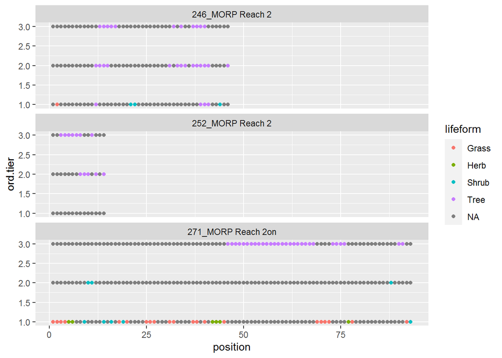

```r
ll.sp %>% filter(str_detect(filter_id, "MORP Reach 2")) %>% ggplot(aes(x = position, y = ord.tier, z = hits, color = lifeform))+
  geom_point()+
  facet_wrap(~filter_id, ncol=1)
```

### MORP Reach 3

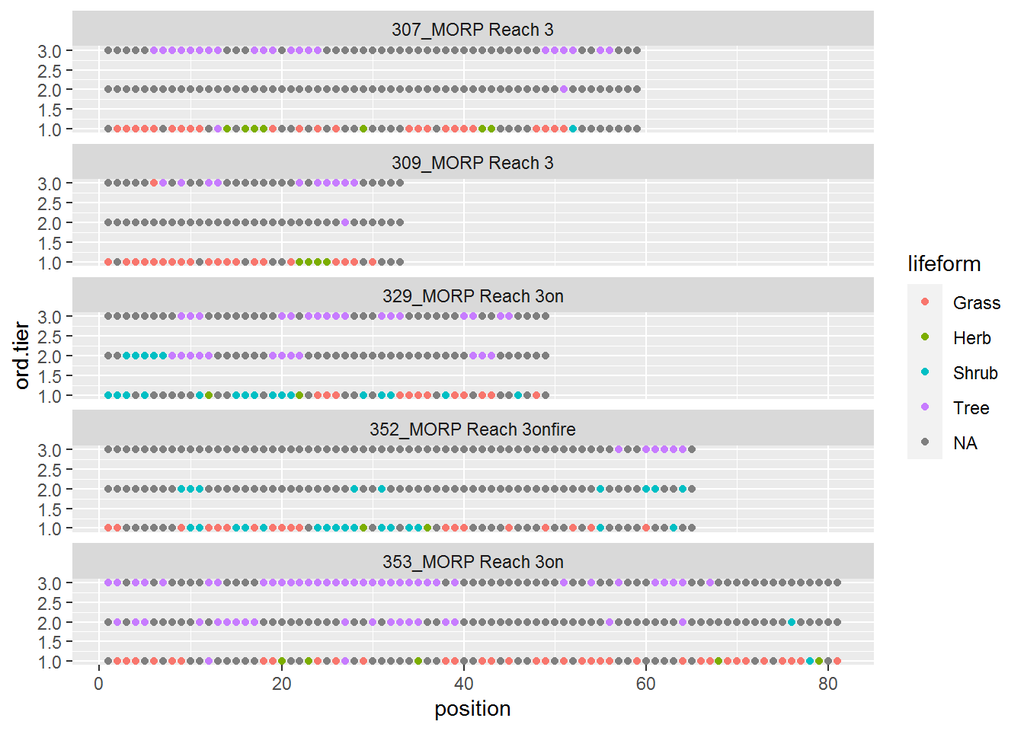

```r
ll.sp%>% filter(str_detect(filter_id, "MORP Reach 3")) %>% ggplot(aes(x = position, y = ord.tier, z = hits, color = lifeform))+
  geom_point()+
  facet_wrap(~filter_id, ncol=1)
```

### MORP Reach 4

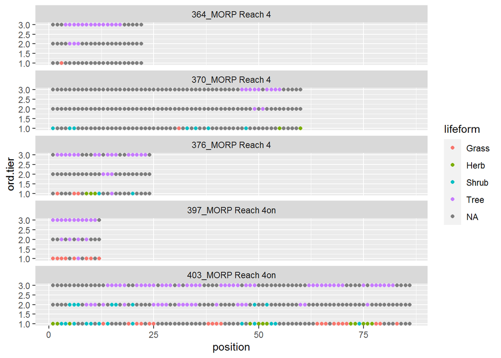

```r
ll.sp%>% filter(str_detect(filter_id, "MORP Reach 4")) %>% ggplot(aes(x = position, y = ord.tier, z = hits, color = lifeform))+
  geom_point()+
  facet_wrap(~filter_id, ncol=1)
```

### MORP Reach 5

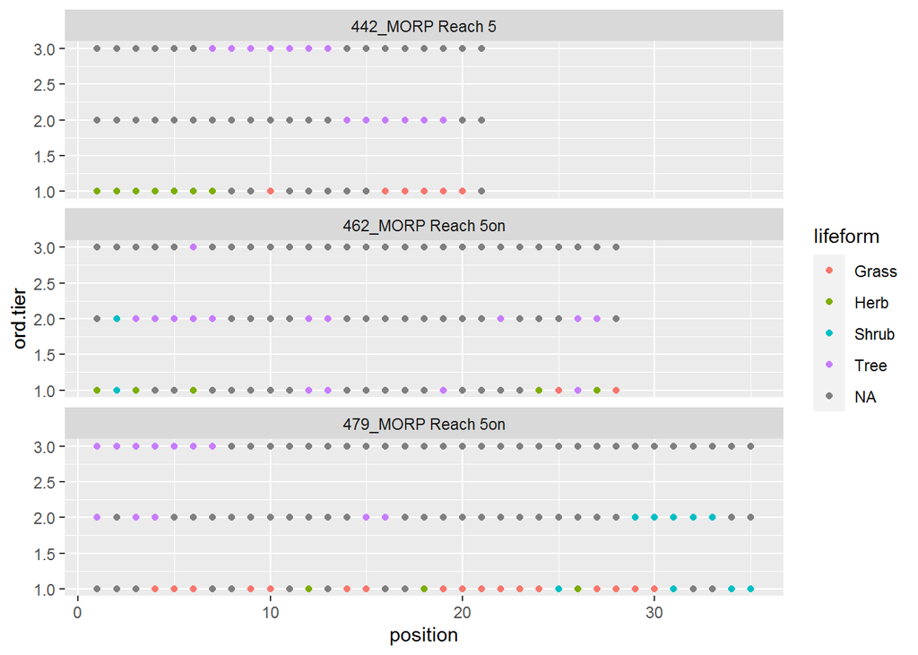

```r
ll.sp%>% filter(str_detect(filter_id, "MORP Reach 5")) %>% ggplot(aes(x = position, y = ord.tier, z = hits, color = lifeform))+
  geom_point()+
  facet_wrap(~filter_id, ncol=1)
```

### MORP Reach 6

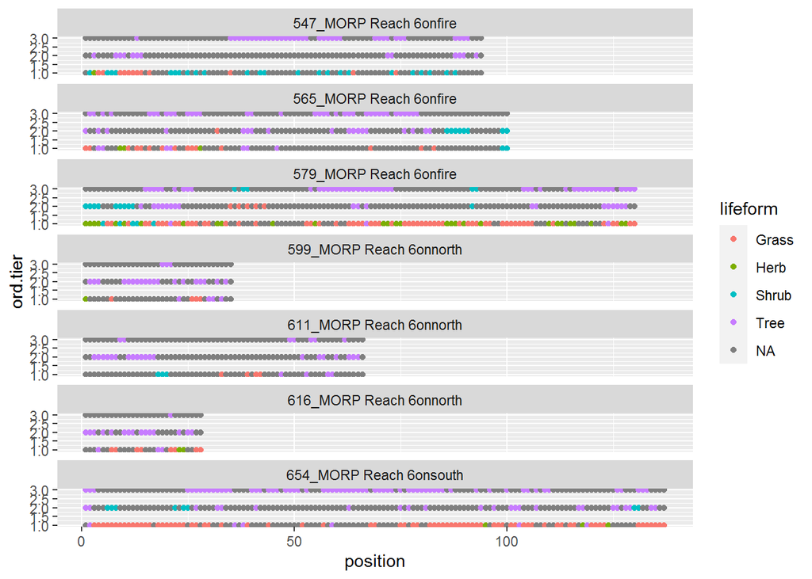

```r
ll.sp%>% filter(str_detect(filter_id, "MORP Reach 6")) %>% ggplot(aes(x = position, y = ord.tier, z = hits, color = lifeform))+
  geom_point()+
  facet_wrap(~filter_id, ncol=1)
```

### LORP

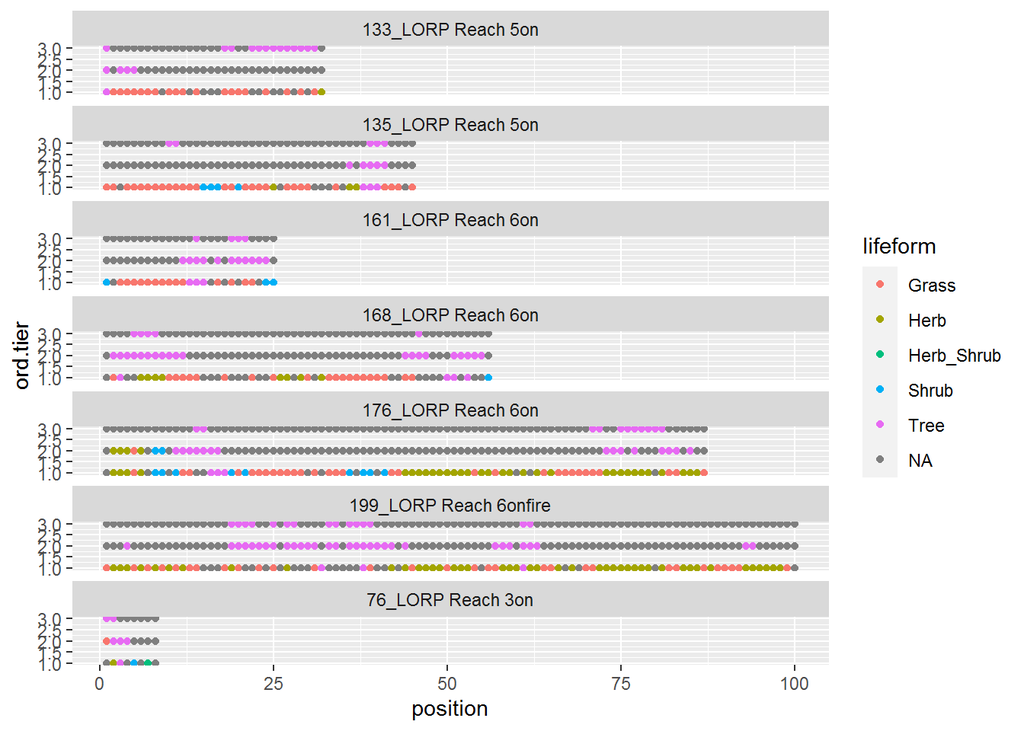

```r
ll.sp%>% filter(str_detect(filter_id, "LORP")) %>% ggplot(aes(x = position, y = ord.tier, z = hits, color = lifeform))+
  geom_point()+
  facet_wrap(~filter_id, ncol=1)
```

```r
# ll.sp%>% filter(str_detect(filter_id, "LORP"))

#presence of steph as subshrub adds category and changes color coding using the auto palette.
```

compute the possible hits for each transect

```r
tier.n.possible <- ll.sp %>% group_by(filter_id, ord.tier) %>% summarise(possible.hits = n())


tier.n.possible
```

| filter_id | ord.tier | possible.hits |
| --- | --- | --- |
| 133_LORP Reach 5on | 1 | 32 |
| 133_LORP Reach 5on | 2 | 32 |
| 133_LORP Reach 5on | 3 | 32 |
| 135_LORP Reach 5on | 1 | 45 |
| 135_LORP Reach 5on | 2 | 45 |
| 135_LORP Reach 5on | 3 | 45 |
| 161_LORP Reach 6on | 1 | 25 |
| 161_LORP Reach 6on | 2 | 25 |
| 161_LORP Reach 6on | 3 | 25 |
| 168_LORP Reach 6on | 1 | 56 |

[output cut: 98 more lines]

```r
tier.sp.hits <- ll.sp %>% group_by(filter_id, ord.tier, species, sci_name, common_name, lifeform, lifecycle, veg_type) %>% summarise(actual.hits = sum(hits)) %>% relocate(actual.hits)


tier.sp.hits
```

| actual.hits | filter_id | ord.tier | species | sci_name | common_name | lifeform | lifecycle | veg_type |
| --- | --- | --- | --- | --- | --- | --- | --- | --- |
| 15 | 133_LORP Reach 5on | 1 | DISP | Distichlis spicata | Saltgrass | Grass | Perennial | grass |
| 3 | 133_LORP Reach 5on | 1 | ELTR3 | Elymus tritocoides | wildrye, Beardless/Creeping | Grass | Perennial | grass |
| 1 | 133_LORP Reach 5on | 1 | HECU3 | Heliotropium curassavicum | heliotrope, Salt | Herb | Perennial | forb |
| 2 | 133_LORP Reach 5on | 1 | litter | NA | NA | NA | NA | NA |
| 1 | 133_LORP Reach 5on | 1 | SALA3 | Salix laevigata | willow, Red | Tree | Perennial | shrub |
| 1 | 133_LORP Reach 5on | 1 | SPAI | Sporobolus airoides | sacaton, Alkali | Grass | Perennial | grass |
| 9 | 133_LORP Reach 5on | 1 | standing dead | NA | NA | NA | NA | NA |
| 4 | 133_LORP Reach 5on | 2 | SALA3 | Salix laevigata | willow, Red | Tree | Perennial | shrub |
| 0 | 133_LORP Reach 5on | 2 | NA | NA | NA | NA | NA | NA |
| 13 | 133_LORP Reach 5on | 3 | SALA3 | Salix laevigata | willow, Red | Tree | Perennial | shrub |

[output cut: 469 more lines]

join the columns actual and possible hits

```r
tier.sp.cover <- tier.sp.hits %>% left_join(tier.n.possible, by = c('filter_id', 'ord.tier')) %>% mutate(tier.sp.cov = round(actual.hits/possible.hits * 100,digits = 2)) %>% relocate(where(is.numeric), .after = species) %>% relocate(ord.tier, .after = filter_id)

tier.sp.cover
```

| filter_id | ord.tier | species | actual.hits | possible.hits | tier.sp.cov | sci_name | common_name | lifeform | lifecycle | veg_type |
| --- | --- | --- | --- | --- | --- | --- | --- | --- | --- | --- |
| 133_LORP Reach 5on | 1 | DISP | 15 | 32 | 46.88 | Distichlis spicata | Saltgrass | Grass | Perennial | grass |
| 133_LORP Reach 5on | 1 | ELTR3 | 3 | 32 | 9.38 | Elymus tritocoides | wildrye, Beardless/Creeping | Grass | Perennial | grass |
| 133_LORP Reach 5on | 1 | HECU3 | 1 | 32 | 3.12 | Heliotropium curassavicum | heliotrope, Salt | Herb | Perennial | forb |
| 133_LORP Reach 5on | 1 | litter | 2 | 32 | 6.25 | NA | NA | NA | NA | NA |
| 133_LORP Reach 5on | 1 | SALA3 | 1 | 32 | 3.12 | Salix laevigata | willow, Red | Tree | Perennial | shrub |
| 133_LORP Reach 5on | 1 | SPAI | 1 | 32 | 3.12 | Sporobolus airoides | sacaton, Alkali | Grass | Perennial | grass |
| 133_LORP Reach 5on | 1 | standing dead | 9 | 32 | 28.12 | NA | NA | NA | NA | NA |
| 133_LORP Reach 5on | 2 | SALA3 | 4 | 32 | 12.50 | Salix laevigata | willow, Red | Tree | Perennial | shrub |
| 133_LORP Reach 5on | 2 | NA | 0 | 32 | 0.00 | NA | NA | NA | NA | NA |
| 133_LORP Reach 5on | 3 | SALA3 | 13 | 32 | 40.62 | Salix laevigata | willow, Red | Tree | Perennial | shrub |

[output cut: 469 more lines]

total cover at transect-tier

```r
tran.tier.cover <- tier.sp.cover %>% group_by(filter_id,ord.tier) %>% summarise(tier.tot.cov = sum(tier.sp.cov))

tran.tier.cover %>% paged_table()
```

| filter_id | ord.tier | tier.tot.cov |
| --- | --- | --- |
| 133_LORP Reach 5on | 1 | 99.99 |
| 133_LORP Reach 5on | 2 | 12.50 |
| 133_LORP Reach 5on | 3 | 40.62 |
| 135_LORP Reach 5on | 1 | 99.99 |
| 135_LORP Reach 5on | 2 | 11.11 |
| 135_LORP Reach 5on | 3 | 11.11 |
| 161_LORP Reach 6on | 1 | 100.00 |
| 161_LORP Reach 6on | 2 | 44.00 |
| 161_LORP Reach 6on | 3 | 16.00 |
| 168_LORP Reach 6on | 1 | 100.02 |

[output cut: 98 more lines]

```r
tran.tier.cover.wide <- tran.tier.cover %>% pivot_wider(names_from = ord.tier, values_from = tier.tot.cov, names_prefix = 'tier_')
```

```r
# convert to wide format for map popup cover by transect tier
```

total cover at transect-tier-lifeform

```r
tier.sp.cover %>% group_by(filter_id,ord.tier,lifeform) %>% summarise(tier.lifeform.tot = sum(tier.sp.cov),species.n = n())
```

| filter_id | ord.tier | lifeform | tier.lifeform.tot | species.n |
| --- | --- | --- | --- | --- |
| 133_LORP Reach 5on | 1 | Grass | 59.38 | 3 |
| 133_LORP Reach 5on | 1 | Herb | 3.12 | 1 |
| 133_LORP Reach 5on | 1 | Tree | 3.12 | 1 |
| 133_LORP Reach 5on | 1 | NA | 34.37 | 2 |
| 133_LORP Reach 5on | 2 | Tree | 12.50 | 1 |
| 133_LORP Reach 5on | 2 | NA | 0.00 | 1 |
| 133_LORP Reach 5on | 3 | Tree | 40.62 | 1 |
| 133_LORP Reach 5on | 3 | NA | 0.00 | 1 |
| 135_LORP Reach 5on | 1 | Grass | 62.22 | 4 |
| 135_LORP Reach 5on | 1 | Herb | 6.66 | 2 |

[output cut: 294 more lines]

show bar plots cover by transect, tier, lifeform

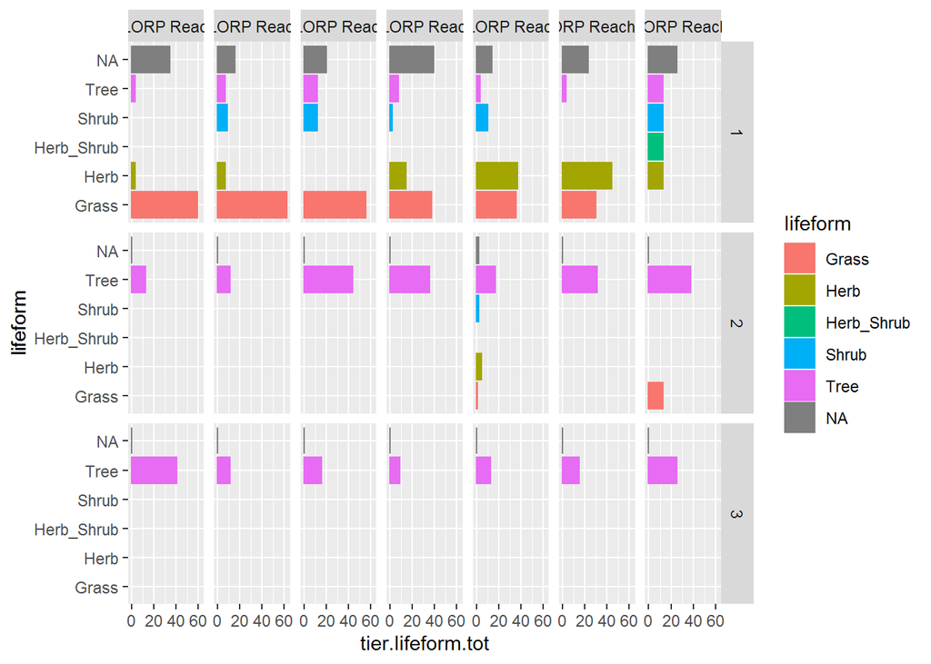

```r
tier.sp.cover %>% filter(str_detect(filter_id, "LORP")) %>% group_by(filter_id,ord.tier,lifeform) %>% summarise(tier.lifeform.tot = sum(tier.sp.cov),species.n = n()) %>% ggplot(aes(x = tier.lifeform.tot , y = lifeform,color = lifeform, fill = lifeform))+
  geom_col()+
  facet_grid(ord.tier~filter_id)
```

## Tree Health

summarise tree variables at the transect level. revisit for reach or other strata aggregations

first split filter_id into separate columns

```r
bc <- belt.count %>% separate(col = filter_id, into = c("id", "last"), sep = "_", remove = 'FALSE') %>% separate(col = last, into = c('reach','strata.combined'), sep = 12) %>% separate(col = strata.combined, into = c('on.river','strata.combined'), sep = 2)

bc %>% paged_table()
```

| filter_id | id | reach | on.river | strata.combined | date | obs | location_on_tape_centerline_m | r_or_l_of_centerline_facing_transect_end_points | distance_from_centerline_m | circumference | dbh_cm | ht_dbh_m_basal_0 | potential_canopy_cover_percent | tree_height_m | species | trunk_angle_degree | size_class_main_trunk_see_table | size_class_resprout | cored_y_n | if_cored_gps_point_number | clone_vegetative_reprod | type_sprout_branch_or_stump | number_resprout_estimate | notes | x22 | x23 | hydro_notes_w_keith |
| --- | --- | --- | --- | --- | --- | --- | --- | --- | --- | --- | --- | --- | --- | --- | --- | --- | --- | --- | --- | --- | --- | --- | --- | --- | --- | --- | --- |
| 76_LORP Reach 3on | 76 | LORP Reach 3 | on |  | 2020-07-09 | MJ | 0.00 | R | 0.00 | 84.00 | 26.751592 | 7.60 | 55 | 7.00 | SAGO | NA | O | NA | yes | 76_LORP_R3_on_t1_SALA3 | NA | NA | NA | Height, potential canopy, core sample taken on 9/30/2020. Only 1 core taken because pith capured (we think) | NA | NA | NA |
| 76_LORP Reach 3on | 76 | LORP Reach 3 | on |  | 2020-07-09 | MJ | 2.00 | R | 0.50 | 120.00 | 38.216561 | 6.40 | 75 | 6.10 | SAGO | NA | O | NA | NA | NA | NA | NA | NA | Main trunk severely damaged & many small living limbs have kept tree alive. Height potential canopy taken on 9/30/2020 | NA | NA | NA |
| 76_LORP Reach 3on | 76 | LORP Reach 3 | on |  | 2020-07-09 | MJ | 1.00 | R | 2.50 | 143.00 | 45.541401 | 5.00 | 25 | 5.60 | SAGO | NA | O | NA | NA | NA | NA | NA | NA | Main trunk severely damaged, a few large stump-sprouts alive. Height potential canopy taken on 9/30/2020 | NA | NA | NA |
| 462_MORP Reach 5on | 462 | MORP Reach 5 | on |  | 2020-07-13 | MJ | 2.00 | R | 3.00 | 36.00 | 11.464968 | 0.50 | 95 | 5.50 | TARA | NA | P | NA | NA | NA | NA | NA | NA | Has multiple stems. DBH taken at 0.5 m | NA | NA | NA |
| 462_MORP Reach 5on | 462 | MORP Reach 5 | on |  | 2020-07-13 | MJ | 5.00 | R | 5.00 | 65.00 | 20.700637 | 0.50 | 75 | 4.50 | TARA | NA | O | NA | NA | NA | NA | NA | NA | Has multiple stems. DBH taken at 0.5 m | NA | NA | NA |
| 462_MORP Reach 5on | 462 | MORP Reach 5 | on |  | 2020-07-13 | MJ | 14.00 | R | 0.75 | 135.00 | 42.993631 | 0.50 | 10 | 7.80 | SALA3 | 45 | O | NA | NA | NA | NA | NA | NA | DBH taken at 0.5 m. Main trunk broken at 3-4m. Beaver activity present on smaller resprouted limbs | NA | NA | NA |
| 462_MORP Reach 5on | 462 | MORP Reach 5 | on |  | 2020-07-13 | MJ | 14.70 | R | 0.75 | 150.00 | 47.770701 | NA | 30 | 7.30 | SALA3 | 35 | O | NA | NA | NA | NA | NA | NA | Main trunk severely damaged at 4m | NA | NA | NA |
| 462_MORP Reach 5on | 462 | MORP Reach 5 | on |  | 2020-07-13 | MJ | 14.70 | L | 0.00 | 150.00 | 47.770701 | NA | 75 | 7.60 | SALA3 | 10 | O | NA | NA | NA | NA | NA | NA | NA | NA | NA | NA |
| 462_MORP Reach 5on | 462 | MORP Reach 5 | on |  | 2020-07-13 | MJ | 14.90 | R | 2.00 | 167.00 | 53.184713 | NA | 50 | 6.90 | SALA3 | 40 | L | NA | Y | 462_MORP_R5_on_t1_SALA3 | NA | NA | NA | Core was rotten in middle | NA | NA | NA |
| 462_MORP Reach 5on | 462 | MORP Reach 5 | on |  | 2020-07-13 | MJ | 16.00 | R | 0.50 | 115.00 | 36.624204 | NA | 5 | 2.10 | SALA3 | NA | O | NA | NA | NA | NA | NA | NA | main trunk severed at 0.5m resprout | NA | NA | NA |

[output cut: 765 more lines]

```r
# filter(!is.na(potential_canopy_cover_percent)) %>%
# to compute summaries, remove NAs
pccp <- bc %>%  filter(!is.na(potential_canopy_cover_percent)) %>% group_by(filter_id) %>% summarise(mean_pccp = mean(potential_canopy_cover_percent),
                                                 min_pccp = min(potential_canopy_cover_percent),
                                                 max_ppcp = max(potential_canopy_cover_percent),
                                                 n_ppcp = n()
                                                 )
# pccp <- bc %>%   group_by(filter_id) %>% summarise(mean_pccp = mean(potential_canopy_cover_percent),
#                                                  min_pccp = min(potential_canopy_cover_percent),
#                                                  max_ppcp = max(potential_canopy_cover_percent),
#                                                  n_ppcp = n()
#                                                  )
paged_table(pccp)
```

| filter_id | mean_pccp | min_pccp | max_ppcp | n_ppcp |
| --- | --- | --- | --- | --- |
| 133_LORP Reach 5on | 63.50000 | 40 | 90 | 10 |
| 135_LORP Reach 5on | 51.87500 | 30 | 75 | 8 |
| 161_LORP Reach 6on | 63.33333 | 30 | 95 | 6 |
| 168_LORP Reach 6on | 64.11765 | 10 | 90 | 17 |
| 176_LORP Reach 6on | 64.37500 | 30 | 85 | 16 |
| 199_LORP Reach 6onfire | 71.06383 | 10 | 100 | 188 |
| 246_MORP Reach 2 | 81.87500 | 45 | 95 | 8 |
| 252_MORP Reach 2 | 75.00000 | 70 | 80 | 3 |
| 271_MORP Reach 2on | 65.62500 | 25 | 95 | 8 |
| 307_MORP Reach 3 | 68.00000 | 30 | 95 | 10 |

[output cut: 20 more lines]

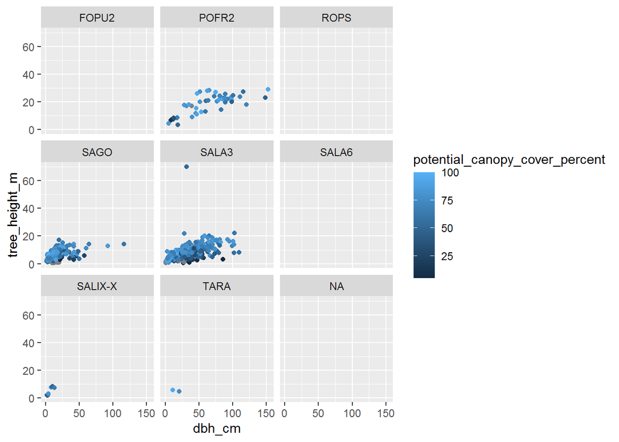

```r
bc %>% ggplot(aes(x = dbh_cm, y = tree_height_m, color = potential_canopy_cover_percent))+
  geom_point()+
  facet_wrap(~species)
```

```r
# species
```

## Canopy Cover by transect

spherical densiometer summarise the 4

```r
# s.dens
# sd_green_reading_out_of_96

# mj mentions averaging by subtransects. revisit that later
s.dens
```

| filter_id | location_m_on_transect_example | sd_green_reading_out_of_96 | direction | x0 | fluvial_surface | notes | densiometer_at_start_point_or_at_regular_intervals_given_here |
| --- | --- | --- | --- | --- | --- | --- | --- |
| 76_LORP Reach 3on | 0 | 57 | Facing channel | NA | channel | On edge of channel/bank | NA |
| 76_LORP Reach 3on | 0 | 31 | Upstream | NA | channel | NA | NA |
| 76_LORP Reach 3on | 0 | 23 | Downstream | NA | channel | NA | NA |
| 76_LORP Reach 3on | 0 | 53 | Facing bank | NA | channel | NA | NA |
| 462_MORP Reach 5on | 0 | 3 | facing channel | NA | NA | NA | NA |
| 462_MORP Reach 5on | 0 | 10 | Upstream | NA | NA | NA | NA |
| 462_MORP Reach 5on | 0 | 13 | Facing bank | NA | NA | NA | NA |
| 462_MORP Reach 5on | 0 | 1 | Downstream | NA | NA | NA | NA |
| 462_MORP Reach 5on | 10 | 5 | Facing channel | NA | NA | NA | NA |
| 462_MORP Reach 5on | 10 | 0 | Upstream | NA | NA | NA | NA |

[output cut: 726 more lines]

average 4 spherical densiometer readings over 4 directions for each location on transect

```r
s_dens_sum <- s.dens %>% filter(!is.na(sd_green_reading_out_of_96)) %>% group_by(filter_id,location_m_on_transect_example) %>% summarise(mean_dens = mean(sd_green_reading_out_of_96),
                                                 min_dens = min(sd_green_reading_out_of_96),
                                                 max_dens = max(sd_green_reading_out_of_96),
                                                 n_dens = n()
                                                 )

paged_table(s_dens_sum)
```

| filter_id | location_m_on_transect_example | mean_dens | min_dens | max_dens | n_dens |
| --- | --- | --- | --- | --- | --- |
| 133_LORP Reach 5on | 0 | 54.75 | 35 | 67 | 4 |
| 133_LORP Reach 5on | 10 | 6.50 | 0 | 18 | 4 |
| 133_LORP Reach 5on | 20 | 43.25 | 3 | 65 | 4 |
| 133_LORP Reach 5on | 30 | 11.50 | 0 | 32 | 4 |
| 135_LORP Reach 5on | 0 | 9.75 | 5 | 21 | 4 |
| 135_LORP Reach 5on | 10 | 12.50 | 0 | 27 | 4 |
| 135_LORP Reach 5on | 20 | 0.25 | 0 | 1 | 4 |
| 135_LORP Reach 5on | 30 | 1.00 | 0 | 4 | 4 |
| 135_LORP Reach 5on | 40 | 53.25 | 28 | 67 | 4 |
| 161_LORP Reach 6on | 0 | 0.00 | 0 | 0 | 4 |

[output cut: 174 more lines]

aggregating to transect level

```r
s_dens_sum_tran <-  s_dens_sum %>% group_by(filter_id) %>% summarise(mean_dens_tran = mean(mean_dens),
                                                 min_dens_tran = min(min_dens),
                                                 max_dens_tran = max(max_dens),
                                                 n_dens_tran = n()
                                                 )

paged_table(s_dens_sum_tran)
```

| filter_id | mean_dens_tran | min_dens_tran | max_dens_tran | n_dens_tran |
| --- | --- | --- | --- | --- |
| 133_LORP Reach 5on | 29.00000 | 0 | 67 | 4 |
| 135_LORP Reach 5on | 15.35000 | 0 | 67 | 5 |
| 161_LORP Reach 6on | 23.50000 | 0 | 69 | 3 |
| 168_LORP Reach 6on | 25.62500 | 0 | 73 | 6 |
| 176_LORP Reach 6on | 19.50000 | 0 | 91 | 9 |
| 199_LORP Reach 6onfire | 30.22727 | 0 | 93 | 11 |
| 246_MORP Reach 2 | 35.00000 | 0 | 93 | 5 |
| 252_MORP Reach 2 | 41.12500 | 0 | 81 | 2 |
| 271_MORP Reach 2on | 27.67500 | 0 | 87 | 10 |
| 307_MORP Reach 3 | 37.87500 | 0 | 84 | 6 |

[output cut: 20 more lines]

## Age Size Structure

### DBH by transect

```r
# dbh

# tree height by species, transect, reach

# proportion and location of trees in sapling size class (non-clonal)
# proportion clonal individuals by  species and reach
dbh_transect_mean <- bc %>% filter(!is.na(dbh_cm)) %>% group_by(filter_id) %>% summarise(mean_dbh_cm = mean(dbh_cm),
                                                 min_dbh_cm = min(dbh_cm),
                                                 max_dbh_cm = max(dbh_cm),
                                                 n_dbh_cm = n()
                                                 )

paged_table(dbh_transect_mean)
```

| filter_id | mean_dbh_cm | min_dbh_cm | max_dbh_cm | n_dbh_cm |
| --- | --- | --- | --- | --- |
| 133_LORP Reach 5on | 35.732229 | 3.300000 | 65.70000 | 10 |
| 135_LORP Reach 5on | 49.175955 | 37.579618 | 73.24841 | 8 |
| 161_LORP Reach 6on | 45.063694 | 14.649682 | 81.05096 | 6 |
| 168_LORP Reach 6on | 32.329412 | 3.800000 | 60.70000 | 17 |
| 176_LORP Reach 6on | 38.818750 | 9.200000 | 116.70000 | 16 |
| 199_LORP Reach 6onfire | 8.401887 | 1.900000 | 19.50000 | 188 |
| 246_MORP Reach 2 | 31.390000 | 3.000000 | 76.70000 | 10 |
| 252_MORP Reach 2 | 61.100000 | 40.300000 | 74.30000 | 3 |
| 271_MORP Reach 2on | 72.212500 | 39.000000 | 153.10000 | 8 |
| 307_MORP Reach 3 | 48.770000 | 18.500000 | 99.00000 | 10 |

[output cut: 20 more lines]

### Tree Height by transect

```r
# dbh

# tree height by species, transect, reach

# proportion and location of trees in sapling size class (non-clonal)
# proportion clonal individuals by  species and reach
tree_height_m_transect_mean <- bc %>% filter(!is.na(tree_height_m)) %>% group_by(filter_id) %>% summarise(mean_height_m = mean(tree_height_m),
                                                 min_tree_height_m = min(tree_height_m),
                                                 max_tree_height_m = max(tree_height_m),
                                                 n_tree_height_m = n()
                                                 )

paged_table(tree_height_m_transect_mean)
```

| filter_id | mean_height_m | min_tree_height_m | max_tree_height_m | n_tree_height_m |
| --- | --- | --- | --- | --- |
| 133_LORP Reach 5on | 8.250000 | 1.60 | 15.0 | 10 |
| 135_LORP Reach 5on | 7.925000 | 5.00 | 9.5 | 8 |
| 161_LORP Reach 6on | 9.968333 | 3.85 | 15.7 | 6 |
| 168_LORP Reach 6on | 6.000000 | 2.10 | 11.2 | 17 |
| 176_LORP Reach 6on | 8.650000 | 3.00 | 14.1 | 16 |
| 199_LORP Reach 6onfire | 5.707632 | 1.20 | 10.8 | 190 |
| 246_MORP Reach 2 | 5.747500 | 1.50 | 9.2 | 8 |
| 252_MORP Reach 2 | 12.233333 | 10.60 | 14.7 | 3 |
| 271_MORP Reach 2on | 14.437500 | 5.60 | 28.9 | 8 |
| 307_MORP Reach 3 | 11.950000 | 3.30 | 22.6 | 10 |

[output cut: 20 more lines]

### Sapling Proportion at Transect

revisit for sapling proportion by species and reach level

Tree size class Criteria

Seedling (S) <1.37 m tall or < 2.5 cm dbh

Pole (P) ≥ 1.37 m and 2.5–15 cm dbh

Overstory tree (O) > 15 cm and <50 cm dbh

Legacy tree (L) ≥ 50 cm dbh

It makes sense to calculate the proportion sapling by species; or at least excluding tara

```r
# Proportion and location of trees in sapling  size class (not clonal or suspected clonal, only seed-recruitment) by transect and reach

# aggregate by reach x species

# sapling non-clonal / total trees
# sapling clonal / total trees



# clonal indicated by a Y

# ZN  resolve this issue

# really this is total stems measured - MJ may group multiple stems into a clonal or resprouted multistemmed morphology
tot_tree_transect <- bc %>% filter(species != 'TARA') %>% group_by(filter_id) %>% summarise(tot.trees = n())

# size class S for seedling
# P for pole

nonclonal.saplings <- bc %>% filter(species != 'TARA') %>% filter(size_class_main_trunk_see_table == 'S',is.na(clone_vegetative_reprod)) %>% group_by(filter_id) %>% summarise(nonclonal.saplings = n())
# the != Y will return P for possible clonal and blank for not clonal. Added P

# return definite clonal and possible clonal stems
clonal.saplings <- bc %>% filter(species != 'TARA') %>% filter(size_class_main_trunk_see_table == 'S', clone_vegetative_reprod %in% c('Y','P'))%>% group_by(filter_id) %>% summarise(clonal.saplings = n())

# unk.saplings <- bc %>% filter(size_class_main_trunk_see_table == 'S', is.na(clone_vegetative_reprod)) %>% group_by(filter_id) %>% summarise(unk.saplings = n())

j <- tot_tree_transect %>% full_join(nonclonal.saplings)%>% full_join(clonal.saplings)
# %>% full_join(unk.saplings)

jj <-j %>%  replace_na(list(nonclonal.saplings = 0, clonal.saplings = 0))

prop_sapling_tran <- jj %>% mutate(prop.nonclonal.saplings = nonclonal.saplings/tot.trees * 100,
              prop.clonal.saplings = clonal.saplings/tot.trees * 100,
              # prop.unk.saplings = unk.saplings/tot.trees * 100,
              tot.saplings = nonclonal.saplings + clonal.saplings)
```

### Join Transect Level Summaries

join all the various summaries at the transect level - one row of summary stats for each transect

```r
tran_rect <- s_dens_sum_tran  %>% full_join(pccp) %>% full_join(dbh_transect_mean) %>% full_join(tree_height_m_transect_mean) %>% full_join(prop_sapling_tran)%>% full_join(tran.tier.cover.wide) %>% separate(col = filter_id, into = c("id", "last"), sep = "_", remove = 'FALSE') %>% separate(col = last, into = c('reach','strata.combined'), sep = 12) %>% separate(col = strata.combined, into = c('on.river','strata.combined'), sep = 2) %>%
  mutate(on.river = case_when(on.river != 'on' ~ 'off river',
                              on.river == 'on' ~ 'on river'),
         fire = if_else(strata.combined == 'fire','fire','no fire'),
         sub.reach.id = case_when(strata.combined == 'north'~'mr6.north',
                                  strata.combined == 'south'~'mr6.south'))



paged_table(tran_rect)
```

| filter_id | id | reach | on.river | strata.combined | mean_dens_tran | min_dens_tran | max_dens_tran | n_dens_tran | mean_pccp | min_pccp | max_ppcp | n_ppcp | mean_dbh_cm | min_dbh_cm | max_dbh_cm | n_dbh_cm | mean_height_m | min_tree_height_m | max_tree_height_m | n_tree_height_m | tot.trees | nonclonal.saplings | clonal.saplings | prop.nonclonal.saplings | prop.clonal.saplings | tot.saplings | tier_1 | tier_2 | tier_3 | … |
| --- | --- | --- | --- | --- | --- | --- | --- | --- | --- | --- | --- | --- | --- | --- | --- | --- | --- | --- | --- | --- | --- | --- | --- | --- | --- | --- | --- | --- | --- | --- |
| 133_LORP Reach 5on | 133 | LORP Reach 5 | on river |  | 29.00000 | 0 | 67 | 4 | 63.50000 | 40 | 90 | 10 | 35.732229 | 3.300000 | 65.70000 | 10 | 8.250000 | 1.60 | 15.0 | 10 | 10 | 0 | 0 | 0.0000000 | 0.0000000 | 0 | 99.99 | 12.50 | 40.62 | … |
| 135_LORP Reach 5on | 135 | LORP Reach 5 | on river |  | 15.35000 | 0 | 67 | 5 | 51.87500 | 30 | 75 | 8 | 49.175955 | 37.579618 | 73.24841 | 8 | 7.925000 | 5.00 | 9.5 | 8 | 8 | 0 | 0 | 0.0000000 | 0.0000000 | 0 | 99.99 | 11.11 | 11.11 | … |
| 161_LORP Reach 6on | 161 | LORP Reach 6 | on river |  | 23.50000 | 0 | 69 | 3 | 63.33333 | 30 | 95 | 6 | 45.063694 | 14.649682 | 81.05096 | 6 | 9.968333 | 3.85 | 15.7 | 6 | 6 | 0 | 0 | 0.0000000 | 0.0000000 | 0 | 100.00 | 44.00 | 16.00 | … |
| 168_LORP Reach 6on | 168 | LORP Reach 6 | on river |  | 25.62500 | 0 | 73 | 6 | 64.11765 | 10 | 90 | 17 | 32.329412 | 3.800000 | 60.70000 | 17 | 6.000000 | 2.10 | 11.2 | 17 | 19 | 0 | 0 | 0.0000000 | 0.0000000 | 0 | 100.02 | 35.71 | 8.93 | … |
| 176_LORP Reach 6on | 176 | LORP Reach 6 | on river |  | 19.50000 | 0 | 91 | 9 | 64.37500 | 30 | 85 | 16 | 38.818750 | 9.200000 | 116.70000 | 16 | 8.650000 | 3.00 | 14.1 | 16 | 16 | 0 | 0 | 0.0000000 | 0.0000000 | 0 | 100.01 | 27.59 | 12.64 | … |
| 199_LORP Reach 6onfire | 199 | LORP Reach 6 | on river | fire | 30.22727 | 0 | 93 | 11 | 71.06383 | 10 | 100 | 188 | 8.401887 | 1.900000 | 19.50000 | 188 | 5.707632 | 1.20 | 10.8 | 190 | 190 | 0 | 6 | 0.0000000 | 3.1578947 | 6 | 100.00 | 31.00 | 15.00 | … |
| 246_MORP Reach 2 | 246 | MORP Reach 2 | off river |  | 35.00000 | 0 | 93 | 5 | 81.87500 | 45 | 95 | 8 | 31.390000 | 3.000000 | 76.70000 | 10 | 5.747500 | 1.50 | 9.2 | 8 | 10 | 0 | 0 | 0.0000000 | 0.0000000 | 0 | 100.00 | 30.43 | 23.91 | … |
| 252_MORP Reach 2 | 252 | MORP Reach 2 | off river |  | 41.12500 | 0 | 81 | 2 | 75.00000 | 70 | 80 | 3 | 61.100000 | 40.300000 | 74.30000 | 3 | 12.233333 | 10.60 | 14.7 | 3 | 3 | 0 | 0 | 0.0000000 | 0.0000000 | 0 | 100.00 | 35.71 | 50.00 | … |
| 271_MORP Reach 2on | 271 | MORP Reach 2 | on river |  | 27.67500 | 0 | 87 | 10 | 65.62500 | 25 | 95 | 8 | 72.212500 | 39.000000 | 153.10000 | 8 | 14.437500 | 5.60 | 28.9 | 8 | 8 | 0 | 0 | 0.0000000 | 0.0000000 | 0 | 64.54 | 4.31 | 31.18 | … |
| 307_MORP Reach 3 | 307 | MORP Reach 3 | off river |  | 37.87500 | 0 | 84 | 6 | 68.00000 | 30 | 95 | 10 | 48.770000 | 18.500000 | 99.00000 | 10 | 11.950000 | 3.30 | 22.6 | 10 | 10 | 0 | 0 | 0.0000000 | 0.0000000 | 0 | 99.97 | 1.69 | 35.59 | … |

[output cut: 26 more lines]

```r
tran_rect %>% distinct(reach)
```

| reach |
| --- |
| LORP Reach 5 |
| LORP Reach 6 |
| MORP Reach 2 |
| MORP Reach 3 |
| MORP Reach 4 |
| MORP Reach 5 |
| MORP Reach 6 |
| LORP Reach 3 |
| 01 |
| 02 |

[output cut: 4 more lines]

```r
# all summaries joined at transect level
# tran_rect %>% write_csv('transect_summary.csv')
```

# Read GIS shapefiles

```r
# read polygons as simple features (sf) object
transects <- st_read("data/transects.shp", quiet = TRUE)
transects.obs <- st_read("data/transect_observations.shp", quiet = TRUE) %>% st_drop_geometry()
# read the quantile levels for each parcel and the current year mean ndvi. This table computed below using the quantile functdion is read in here to display on the map below.
# t <- read_csv(paste0('data/table_quantile_',cYear,'.csv'))
```

```r
str(transects)
```

```
## Classes 'sf' and 'data.frame':   855 obs. of  17 variables:
##  $ Join_Count: num  1 1 1 1 1 1 1 1 2 1 ...
##  $ TARGET_FID: num  1 2 3 4 5 6 7 8 9 10 ...
##  $ Join_Cou_1: num  1 1 1 1 1 1 1 1 1 1 ...
##  $ TARGET_F_1: num  1 2 3 4 5 6 7 8 9 10 ...
##  $ CID       : num  6 6 6 6 6 6 6 6 6 6 ...
##  $ NEAR_X    : num  396413 398021 398064 398935 397849 ...
##  $ NEAR_Y    : num  4082271 4079800 4079754 4074976 4080118 ...
##  $ FROM_X    : num  396226 398004 398069 399186 397998 ...
##  $ FROM_Y    : num  4082145 4079929 4079755 4074927 4080199 ...
##  $ IN_FID    : num  1 2 3 4 5 6 7 8 9 10 ...
##  $ azimuth   : num  236.22 -7.41 89.33 101.13 61.43 ...
##  $ group_id  : chr  "LORP Reach 2" "LORP Reach 2" "LORP Reach 2" "LORP Reach 2" ...
##  $ sample_siz: num  10 10 10 10 10 10 10 10 10 10 ...
##  $ number_poi: num  20 20 20 20 20 20 20 20 20 20 ...
##  $ GlobalID  : chr  "ddba3e74-b3ca-4f2e-ab33-d5b25d07e385" "783f59eb-9149-4804-82b2-1d25b23dee47" "fb063f95-63bb-4957-ae02-1b7c33b94598" "8e1e9f15-5354-47ed-b381-791f76ae584c" ...
##  $ fluvial   : chr  NA NA NA NA ...
##  $ geometry  :sfc_POINT of length 855; first list element:  'XYZ' num  -13154009 4422334 0
##  - attr(*, "sf_column")= chr "geometry"
##  - attr(*, "agr")= Factor w/ 3 levels "constant","aggregate",..: NA NA NA NA NA NA NA NA NA NA ...
##   ..- attr(*, "names")= chr [1:16] "Join_Count" "TARGET_FID" "Join_Cou_1" "TARGET_F_1" ...
```

```r
str(transects.obs)
```

```
## 'data.frame':    81 obs. of  10 variables:
##  $ guid      : chr  "2cab3ae4-7033-4e10-b5b3-496c66ce34b9" "aa36fefd-be97-4db6-86bd-73facf24462d" "8494fcba-31c9-4df5-a28a-3c1c8acd7c2d" "a7bfa31e-5c39-4acb-accb-0b8451e76f0a" ...
##  $ date      : Date, format: "2020-07-09" "2020-07-13" ...
##  $ obs       : chr  "MJ" "MJ" "MJ" "MJ" ...
##  $ notes     : chr  "Recollected point based on accessibility. Photo link not available. Photo taken at 1.5 m looking back at start "| __truncated__ "Metal start tag attached to sapling stump on ground 1ft N of tape" "Start point at bank in tules. Tag is at 1.4 m on small log. Start point is on t…
##  $ lpi_data_l: chr  "insert gsheets link" "insert gsheets link" "insert gsheets link" "insert gsheets link" ...
##  $ beltcount_: chr  "insert gsheets link" "insert gsheets link" "insert gsheets link" "insert gsheets link" ...
##  $ salinity_l: chr  "insert gsheets link" "insert gsheets link" "insert gsheets link" "insert gsheets link" ...
##  $ wse       : chr  "insert gsheets link" "insert gsheets link" "insert gsheets link" "insert gsheets link" ...
##  $ exotic_cov: num  25 25 25 0 25 25 25 5 5 5 ...
##  $ GlobalID  : chr  "a2857c2e-b0e6-40cf-917d-1332daaacc7c" "ed31c532-2481-4bf7-b476-4627feb44d69" "bde1953f-e7c6-4c87-8872-2ac9ffb9971a" "8e813bd0-6687-45a9-a079-8d8e306515c3" ...
```

```r
# transect.obs.joined <- transects %>% left_join(transects.obs, by = c('GlobalID'='guid')


tran_rect$idn <- as.numeric(tran_rect$id)
transect.obs.join <- transects %>% left_join(transects.obs, by = c('GlobalID'='guid')) %>% filter(!is.na(obs)|!is.na(date)) %>% left_join(tran_rect, by = c('IN_FID' = 'idn'))

# IN_FID
# id

transect.obs.joined <- transect.obs.join %>% filter(!is.na(mean_dbh_cm))

names(transect.obs.joined)
```

```
##  [1] "Join_Count"              "TARGET_FID"
##  [3] "Join_Cou_1"              "TARGET_F_1"
##  [5] "CID"                     "NEAR_X"
##  [7] "NEAR_Y"                  "FROM_X"
##  [9] "FROM_Y"                  "IN_FID"
## [11] "azimuth"                 "group_id"
## [13] "sample_siz"              "number_poi"
## [15] "GlobalID"                "fluvial"
## [17] "date"                    "obs"
## [19] "notes"                   "lpi_data_l"
## [21] "beltcount_"              "salinity_l"
## [23] "wse"                     "exotic_cov"
## [25] "GlobalID.y"              "filter_id"
## [27] "id"                      "reach"
## [29] "on.river"                "strata.combined"
## [31] "mean_dens_tran"          "min_dens_tran"
## [33] "max_dens_tran"           "n_dens_tran"
## [35] "mean_pccp"               "min_pccp"
## [37] "max_ppcp"                "n_ppcp"
## [39] "mean_dbh_cm"             "min_dbh_cm"
## [41] "max_dbh_cm"              "n_dbh_cm"
## [43] "mean_height_m"           "min_tree_height_m"
## [45] "max_tree_height_m"       "n_tree_height_m"
## [47] "tot.trees"               "nonclonal.saplings"
## [49] "clonal.saplings"         "prop.nonclonal.saplings"
## [51] "prop.clonal.saplings"    "tot.saplings"
## [53] "tier_1"                  "tier_2"
## [55] "tier_3"                  "fire"
## [57] "sub.reach.id"            "geometry"
```

# Map

```r
# show a dynamic map of the monitoring area
tmap_mode("view")

tm_basemap(leaflet::providers$Esri.WorldImagery) +
  # all points
   tm_shape(transect.obs.join) +
  tm_dots(id = "group_id",popup.vars = c("group_id","date","obs","fluvial", "exotic_cov"),alpha =1, col = 'yellow')+
  # just start points with data linked
  tm_shape(transect.obs.joined) +
  tm_dots(id = "group_id",popup.vars = c("group_id","filter_id","date","fluvial","fire","on.river","tier_1","tier_2","tier_3","exotic_cov","mean_dens_tran","mean_pccp","mean_height_m","mean_dbh_cm","prop.nonclonal.saplings","prop.clonal.saplings"  ),alpha =1, col = 'red')+

  # tm_shape()
# tm_polygons(col =c("mean.ndvi"),title = "Mean NDVI 2020 (Jul 15 - Sep 5)",legend.hist=TRUE, breaks = c(0,.1,.2,.3,.4,.5,.6), palette = "Greens",title.col = "PCL",  id = "PCL",popup.vars = c("PCL","GB_TYPE.x","COMM_NAME.x","mean.ndvi", "20%", "above0.2"),alpha =.4)+
# tm_layout(main.title = "Mean NDVI 2020(Jul 15 - Sep 15)",
          # legend.title.size = 1,
          # legend.text.size = 0.6,
          # legend.bg.color = "white",
          # legend.bg.alpha = 1
          # )+
  tm_view(legend.position = c("right","top"))
```

[interactive chart not shown]

```r
# save the map as a stand alone html web map
# tmap_save(filename = "typeD2020pilot.html")
```

red symbols have the transect level data in the popup window